# Aviation Crash Analysis Final Notebook

# Changing missing spaces and dashes into NA

```r
# Changing missing spaces and dashes into NA

aero$Location <- ifelse(aero$Location == "", NA, aero$Location)
aero$Operator <- ifelse(aero$Operator == "", NA, aero$Operator)
aero$Flight.. <- ifelse(aero$Flight.. == "", NA, aero$Flight..)
aero$Flight.. <- ifelse(aero$Flight.. == "-", NA, aero$Flight..)
aero$Route <- ifelse(aero$Route == "", NA, aero$Route)
aero$Type <- ifelse(aero$Type == "", NA, aero$Type)
aero$Registration <- ifelse(aero$Registration == "", NA, aero$Registration)
aero$cn.In <- ifelse(aero$cn.In == "", NA, aero$cn.In)
aero$Summary <- ifelse(aero$Summary == "", NA, aero$Summary)

aero <- aero[!is.na(aero$Summary), ] # Remove NA Summary rows
```

```r
head(aero$Date)
```

```
[1] "09/17/1908" "07/12/1912" "08/06/1913" "09/09/1913" "10/17/1913" "03/05/1915"
```

# Convert Date to a date type variable

```r
aero$Date <- as.Date(aero$Date, format = "%m/%d/%Y")
```

# Percentage of missing values in each column

```r
misscol <- colSums(is.na(aero)) / nrow(aero)
round(misscol, 3)
```

```
            Date             Time         Location         Operator         Flight..            Route             Type     Registration            cn.In
           0.000            0.000            0.003            0.003            0.796            0.276            0.004            0.056            0.203
          Aboard       Fatalities           Ground          Summary Total_Fatalities   Crash_Severity
           0.000            0.000            0.000            0.000            0.000            0.000
```

Date has no missing values. We can pull the year into a new variable

```r
# Create Year as a Date and convert it into a numeric

aero$Year <- format(as.Date(aero$Date), "%Y")
aero$Year <- as.numeric(as.character(aero$Year))
```

# EDA Year & Date

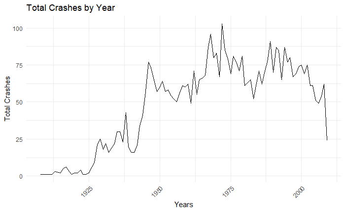

```r
# Line plot of Crashes by year

year_count <- aero %>%
  group_by(Year) %>%
  summarise(Crashes = n())

ggplot(year_count, aes(x = Year, y = Crashes)) +
  geom_line() +
  labs(title = "Total Crashes by Year", x = "Years", y = "Total Crashes") +
  theme_minimal() +
  theme(axis.text.x = element_text(angle = 45, hjust = 1))
```

1972 had the most plane crashes

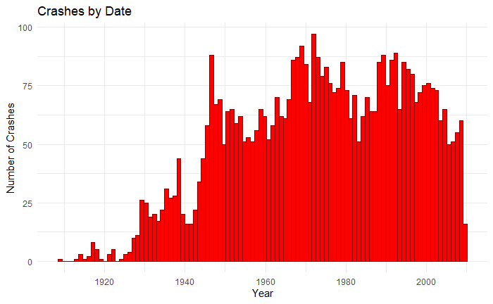

```r
# Histogram of Crashes by Date


crashes_by_date <- ggplot(aero, aes(x = Date)) +
  geom_histogram(bins = 100, fill = "red", color = "darkred") +
  labs(title = "Crashes by Date", x = "Year", y = "Number of Crashes") +
  theme_minimal()

print(crashes_by_date)
```

Summary will be useful for creating new columns.

Location, Operator and Type all have less than 1% missing values

# Replace NA in Location, Operator and Type with “Unavailable”

```r
# replace NA with "unavailable"

aero <- aero %>%
  dplyr::mutate(Location = replace(Location, is.na(Location), "Unavailable")) %>%
  dplyr::mutate(Type = replace(Type, is.na(Type), "Unavailable")) %>%
  dplyr::mutate(Operator = replace(Operator, is.na(Operator), "Unavailable"))
```

Now we have enough data to get a good visual representation

# EDA Total Fatalities and Fatalities

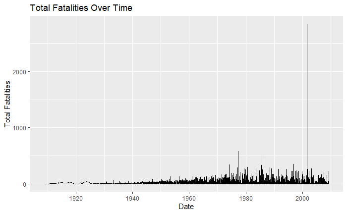

```r
# Total Fatalities over time (ground included)

library(ggplot2)

ggplot(aero, aes(x = Date, y = Total_Fatalities)) +
  geom_line() +
  labs(title = "Total Fatalities Over Time", x = "Date", y = "Total Fatalities")
```

We can see a large spike in 2001 during the Trade Towers terrorist attack for total fatalities. This will be an outlier that we’ll leave in later as we are including acts of war / terrorism.

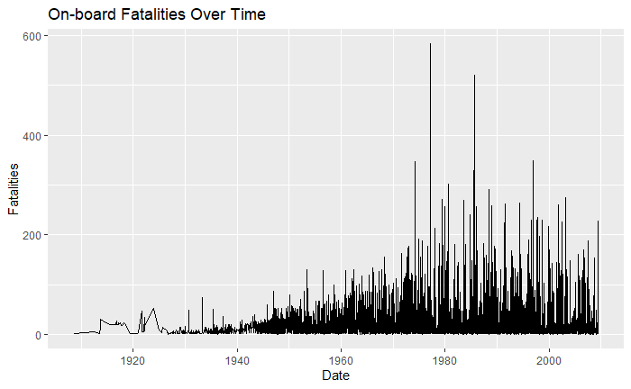

```r
# Fatalities over time (on-board only)

library(ggplot2)


ggplot(aero, aes(x = Date, y = Fatalities)) +
  geom_line() +
  labs(title = "On-board Fatalities Over Time", x = "Date", y = "Fatalities")
```

For fatalities only concerning those aboard the aircraft we can see a spike in the mid-70s.

# Operator EDA

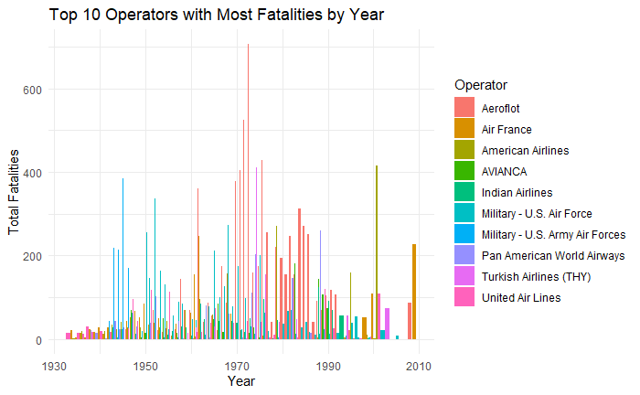

```r
# Top 10 operators with most fatalities by year (grouped bar plot)


# Summarise fatalities by Operator and Year
summary_aero <- aero %>%
  group_by(Operator, Year) %>%
  summarise(Total_Fatalities = sum(Fatalities)) %>%
  ungroup()
# Get top 10 operators with most fatalities
top_operators <- summary_aero %>%
  group_by(Operator) %>%
  summarise(Total_Fatalities = sum(Total_Fatalities)) %>%
  top_n(10, Total_Fatalities) %>%
  pull(Operator)

# Filter the summary data for top operators
top_summary_aero <- summary_aero %>%
  filter(Operator %in% top_operators)

ggplot(top_summary_aero, aes(x = Year, y = Total_Fatalities, fill = Operator)) +
  geom_bar(stat = "identity", position = "dodge") +
  labs(title = "Top 10 Operators with Most Fatalities by Year",
       x = "Year",
       y = "Total Fatalities") +
  theme_minimal()
```

Lets create a survivors variable

# Survivors variable

```r
aero$Survived <- aero$Aboard - aero$Fatalities
```

# Survivors EDA

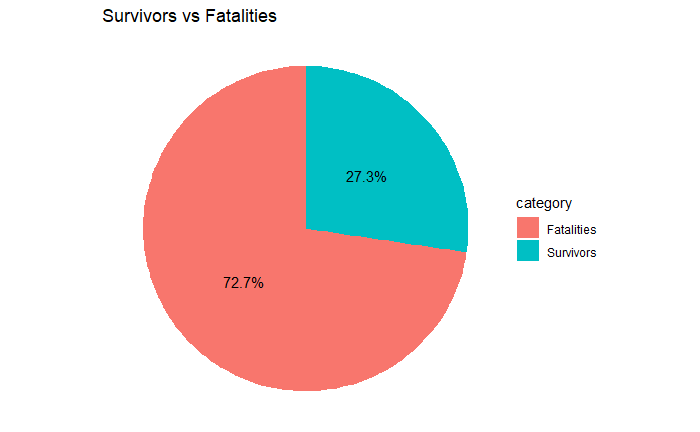

```r
library(scales)

# Create a pie chart

# Summarize the data

data <- data.frame(
  category = c("Survivors", "Fatalities"),
  count = c(sum(aero$Survived), sum(aero$Fatalities))
)

# Calculate percentages

data$percentage <- data$count / sum(data$count) * 100

# Create the pie chart
ggplot(data, aes(x = "", y = count, fill = category)) +
  geom_bar(stat = "identity", width = 1) +
  coord_polar("y", start = 0) +
  theme_void() +
  geom_text(aes(label = paste0(round(percentage, 1), "%")),
            position = position_stack(vjust = 0.5)) +
  labs(title = "Survivors vs Fatalities")
```

We can see 27.3% of people survived aviation crashes and almost three quarters died

# Type EDA

```r
type_fatal <- aero %>%
  group_by(Type) %>%
  summarise(Fatalities = sum(Fatalities))

# View the result
print(type_fatal)
```

| Type | Fatalities |
| --- | --- |
| AAC-1 Toucan | 23 |
| AT L98 Carvair | 4 |
| ATR 42-300 | 2 |
| ATR-42-300 | 46 |
| ATR-72-202 | 16 |
| ATR-72-212 | 68 |
| Aermacchi MB-339PAN (3 aircraft) | 3 |
| Aero Commander 520 | 6 |
| Aero Commander 500-B | 2 |
| Aero Commander 500A | 7 |

[output cut: 990 more lines]

```r
NA
```

```r
fatal_Top10_Type <- aero %>%
  group_by(Type) %>%
  summarise(Fatalities = sum(Fatalities)) %>%
  rename(Aircraft_Type = Type) %>%
  arrange(desc(Fatalities)) %>%
  slice_head(n = 10)

# View the result
print(fatal_Top10_Type)
```

| Aircraft_Type | Fatalities |
| --- | --- |
| Douglas DC-3 | 4594 |
| Douglas DC-6B | 1052 |
| Douglas C-47 | 1035 |
| Antonov AN-26 | 1022 |
| McDonnell Douglas DC-9-32 | 951 |
| Douglas DC-4 | 925 |
| Yakovlev YAK-40 | 814 |
| Tupolev TU-134A | 809 |
| McDonnell Douglas DC-10-10 | 804 |
| Ilyushin IL-18B | 791 |

```r
NA
```

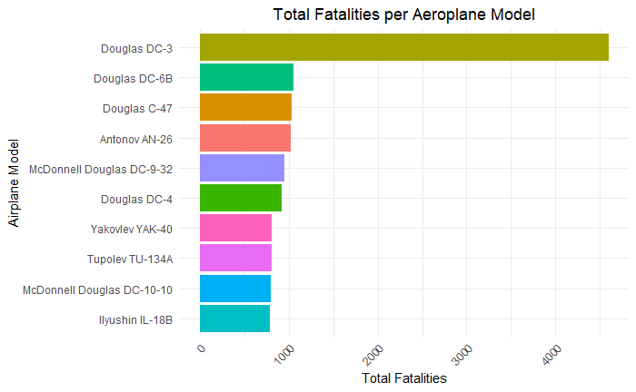

```r
fatal_Top10_Type <- fatal_Top10_Type %>%
  arrange(desc(Fatalities)) %>%
  slice_head(n = 10)

# Create the bar plot
ggplot(fatal_Top10_Type, aes(x = reorder(Aircraft_Type, Fatalities), y = Fatalities, fill = Aircraft_Type)) +
  geom_bar(stat = "identity") +
  coord_flip() +
  labs(title = "Total Fatalities per Aeroplane Model",
       x = "Airplane Model",
       y = "Total Fatalities") +
  theme_minimal() +
  theme(legend.position = "none",
        plot.title = element_text(hjust = 0.5),
        axis.text.x = element_text(angle = 45, hjust = 1))
```

Let’s fill in missing spaces in Time as NA convert time into a factor and take a look at the missing data again.

```r
# Fill in empty string or those with dashes with NA and change into a factor

aero$Time[aero$Time == ""] <- NA
aero$Time <- ifelse(aero$Time == "-", NA, aero$Time)
aero$Time <- factor(aero$Time)
```

```r
# Check for missing values

misscol <- colSums(is.na(aero)) / nrow(aero)
round(misscol, 3)
```

```
            Date             Time         Location         Operator         Flight..            Route             Type     Registration            cn.In
           0.000            0.378            0.000            0.000            0.796            0.276            0.000            0.056            0.203
          Aboard       Fatalities           Ground          Summary Total_Fatalities   Crash_Severity             Year         Survived
           0.000            0.000            0.000            0.000            0.000            0.000            0.000            0.000
```

Time could potentially be added to date using the lubridate package, however, the data may prove useful if shrunk down to a smaller Categorical times of the day.

We should first check for incorrect variables and correct them if found

```r
wrong_Values <- aero$Time[!grepl("^\\d{2}:\\d{2}$", aero$Time)]

#Print the non-conforming values
print(wrong_Values[!is.na(wrong_Values)])
```

```
 [1] c: 1:00 c:17:00 c: 2:00 c:09:00 1:30    c16:50  12'20   18.40   c:09:00 114:20  c14:30  0943    1:00    2:40    22'08   c: 9:40 2:00    8:02    9:30
1004 Levels: 00:00 00:01 00:02 00:03 00:04 00:05 00:08 00:12 00:13 00:15 00:16 00:20 00:22 00:23 00:25 00:28 00:30 00:31 00:32 00:33 00:34 00:35 00:36 ... c16:50
```

We can see a few non conforming values, such as c: 1:00 12’20. Let’s fix this first

```r
aero$Time <- gsub("^c", "", aero$Time)  # Remove "c:" prefix
aero$Time <- gsub("'", ":", aero$Time) # Replace the apostrophe with a colon
aero$Time <- gsub("^:", "", aero$Time) # Remove leading colon
aero$Time <- trimws(aero$Time) # remove leading space
aero$Time <- sprintf("%02s",aero$Time) # add leading zero
```

We should check to see if there are any remaining incorrect values

```r
# Refresh non_conforming_values

wrong_Values <- aero$Time[!grepl("^\\d{2}:\\d{2}$", aero$Time)]

# We can see a few values still require fixing

unique(wrong_Values)
```

```
 [1] "NA"     "1:00"   "2:00"   "1:30"   "18.40"  "114:20" "0943"   "2:40"   "9:40"   "8:02"   "9:30"
```

There are still incorrect values, though not many. We can fix the values manually though will need their index positions.

```r
# Some values aren't fixed by adding leading zeros. Let's get their indexes and fix them manually

index_of_2_00 <- which(aero$Time == "2:00")
print(index_of_2_00)
```

```
[1]  112 4459
```

```r
index_of_1_00 <- which(aero$Time == "1:00")
print(index_of_1_00)
```

```
[1]   81 3225
```

```r
index_of_1_30 <- which(aero$Time == "1:30")
print(index_of_1_30)
```

```
[1] 484
```

```r
index_of_18_40 <- which(aero$Time == "18.40")
print(index_of_18_40)
```

```
[1] 1668
```

```r
index_of_114_20 <- which(aero$Time == "114:20")
print(index_of_114_20)
```

```
[1] 2932
```

```r
index_of_09430 <- which(aero$Time == "0943")
print(index_of_09430)
```

```
[1] 3179
```

```r
index_of_2_40 <- which(aero$Time == "2:40")
print(index_of_2_40)
```

```
[1] 3919
```

```r
index_of_9_40 <- which(aero$Time == "9:40")
print(index_of_9_40)
```

```
[1] 4449
```

```r
index_of_8_02 <- which(aero$Time == "8:02")
print(index_of_8_02)
```

```
[1] 4460
```

```r
index_of_9_30 <- which(aero$Time == "9:30")
print(index_of_9_30)
```

```
[1] 4767
```

```r
# Manually correct values without leading zeroes or missing colons that for some reason won't adjust.

new_value1 <- "02:00"
aero$Time[229] <- new_value1

new_value2 <- "02:00"
aero$Time[4849] <- new_value2

new_value3 <- "01:00"
aero$Time[191] <- new_value3

new_value4 <- "01:00"
aero$Time[3585] <- new_value4

new_value5 <- "01:30"
aero$Time[712] <- new_value5

new_value6 <- "18:40"
aero$Time[1950] <- new_value6

new_value7 <- "14:20"
aero$Time[3268] <- new_value7

new_value8 <- "09:43"
aero$Time[3537] <- new_value8

new_value9 <- "02:40"
aero$Time[4299] <- new_value9

new_value10 <- "09:40"
aero$Time[4839] <- new_value10

new_value11 <- "08:02"
aero$Time[4850] <- new_value11

#new_value12 <- "09:30"
#aero$Time[5157] <- new_value12
```

# Create a new column named TimeOfDay and add Categorical data

```r
library(lubridate)

# Convert the format to DateTime and extract the hour

aero$Time <- as.POSIXct(aero$Time, format = "%H:%M")
aero$Hour <- hour(aero$Time)


# Take the hour and depending on its value change it into a category

aero$TimeOfDay <- cut(
  aero$Hour,
  breaks = c(0, 6, 12, 18, 24),
  labels = c("Night", "Morning", "Afternoon", "Evening"),
  include.lowest = TRUE # Includes 0:00 in Night
)
```

# EDA TimeOfDay

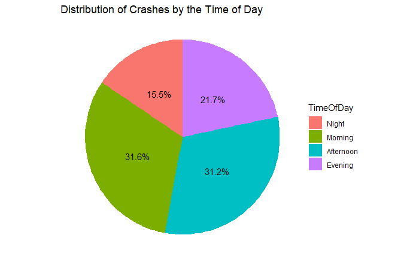

```r
data <- as.data.frame(table(aero$TimeOfDay))
colnames(data) <- c("TimeOfDay", "count")

# Calculate percentages
data$percentage <- data$count / sum(data$count) * 100

# Create the pie chart
ggplot(data, aes(x = "", y = count, fill = TimeOfDay)) +
  geom_bar(stat = "identity", width = 1) +
  coord_polar("y", start = 0) +
  theme_void() +
  geom_text(aes(label = paste0(round(percentage, 1), "%")),
            position = position_stack(vjust = 0.5)) +
  labs(title = "Distribution of Crashes by the Time of Day")
```

We can see that half as many crashes occurred during the night than during morning or afternoon from the data available.

TimeOfDay will need to be label encoded for the Machine Learning algorithms

# Encoding TimeOfDay

```r
# Label Encode TimeOfDay into integers 1, 2, 3, 4 == "Night", "Morning", "Afternoon", "Evening"

aero$TimeOfDay <- as.factor(aero$TimeOfDay)  # Convert to a factor
encoded_data <- data.frame(TimeOfDay = as.integer(aero$TimeOfDay))

aero$Time_Of_Day <- encoded_data$TimeOfDay
```

# Drop Time and Hour from the Dataset

```r
library(dplyr)
aero <- aero %>%
  select(-Time, -Hour)
```

# Search for most frequent words in Summary (Text Mining)

```r
library(tidytext)
library(dplyr)

aero <- as_tibble(aero)

# Tokenize and count words
word_counts <- aero %>%
  unnest_tokens(word, Summary) %>%  # This function splits the text into individual words.
  count(word, sort = TRUE)          # Count occurrences of each word

print(word_counts)
```

| word | n |
| --- | --- |
| the | 15787 |
| a | 4881 |
| to | 4825 |
| and | 4823 |
| of | 4787 |
| in | 3334 |
| crashed | 3214 |
| aircraft | 2403 |
| into | 2345 |
| was | 2266 |

[output cut: 990 more lines]

```r
NA
```

# Word PreProcessing

```r
library(tidyverse)
library(tidytext)
library(SnowballC)

word_counts <- word_counts %>%
  mutate(word = tolower(word)) %>% # make all words lowercase
  mutate(word = str_trim(word)) %>% # remove white space
  mutate(stem = wordStem(word)) %>% # stem words into an additional column
  filter(!word %in% stop_words$word) %>% # remove English stop words
  filter(!grepl("^\\d+(,\\d+)*$", word)) %>% # remove numbers with optional commas
  filter(!grepl("^\\d+(\\.\\d+)?$", word)) %>% # remove numbers with optional decimal places
  filter(!grepl("^[^[:alpha:][:punct:]]+$", word)) # remove punctuation and any character that is not a letter


print(word_counts)
```

| word | n | stem |
| --- | --- | --- |
| crashed | 3214 | crash |
| aircraft | 2403 | aircraft |
| plane | 1839 | plane |
| flight | 1173 | flight |
| pilot | 1101 | pilot |
| approach | 942 | approach |
| engine | 941 | engin |
| runway | 915 | runwai |
| failure | 880 | failur |
| crew | 752 | crew |

[output cut: 990 more lines]

```r
NA
```

# Create new column for cause of crash

```r
# Create a function to map tokens to cause_of_crash values

get_cause_of_crash <- function(tokens) {
  tokens <- gsub("[\\.,]", "", tokens)
  tokens <- tolower(tokens)
  if ("fog" %in% tokens || "storm" %in% tokens || "weather" %in% tokens ||
      "poor" %in% tokens || "rain" %in% tokens || "icing" %in% tokens ||
      "thunderstorm" %in% tokens || "ice" %in% tokens || "thunderstorms" %in% tokens ||
      "storm" %in% tokens || "lightning" %in% tokens || "snow" %in% tokens ||
      "rainstorm" %in% tokens || "gust" %in% tokens || "overcast" %in% tokens ||
      "winds" %in% tokens || "snowstorm" %in% tokens || "winds" %in% tokens ||
      "volcano" %in% tokens || " hurricane" %in% tokens || "tornado" %in% tokens ||
      "meteorological" %in% tokens){
    return("Bad Weather / Natural Disaster")
  } else if ("pilot" %in% tokens || "crew" %in% tokens || "pilot's" %in% tokens ||
             "captain" %in% tokens || "pilots" %in% tokens || "decision" %in% tokens ||
             "fatigue" %in% tokens || "procedure" %in% tokens || "training" %in% tokens ||
             "operation" %in% tokens || "captain's" %in% tokens || "misjudged" %in% tokens ||
             "planning" %in% tokens || "officer" %in% tokens || "judgement" %in% tokens ||
             "experience" %in% tokens || "instructions" %in% tokens || "judgment" %in% tokens ||
             "management" %in% tokens || "crews" %in% tokens || "awareness" %in% tokens ||
             "flightcrew" %in% tokens || "flightcrew's" %in% tokens || "preparation" %in% tokens ||
             "engineer" %in% tokens || "exhaustion" %in% tokens || "operator" %in% tokens ||
             "alcohol" %in% tokens || "incapacitation" %in% tokens || "officer's" %in% tokens) {
    return("Human Error")
  } else if ("war" %in% tokens || "terrorism" %in% tokens || "political" %in% tokens || "shot" %in% tokens ||
             "hijackers" %in% tokens || "suicide" %in% tokens || "hijacker" %in% tokens || "enemy" %in% tokens ||
             "fighters" %in% tokens || "hijacked" %in% tokens || "bomb"  %in% tokens || "bombs" %in% tokens ||
             "mission" %in% tokens || "explosive" %in% tokens || "detonation" %in% tokens || "missile" %in% tokens ||
             "fighter" %in% tokens || "military" %in% tokens || "aircraft" %in% tokens && "fire" %in% tokens ||
             "shelling" %in% tokens) {
    return("Act of War / Terrorism")
  } else if ("mechanical" %in% tokens || "failure" %in% tokens || "engine" %in% tokens || "wing" %in% tokens ||
             "power" %in% tokens || "engines" %in% tokens || "instrument" %in% tokens || "nose" %in% tokens ||
             "gear" %in% tokens || "system" %in% tokens || "propeller"  %in% tokens || "burst" %in% tokens ||
             "aircraft's" %in% tokens || "cockpit"  %in% tokens || "radar" %in% tokens || "fuselage" %in% tokens ||
             "flaps" %in% tokens || "navigational" %in% tokens || "rudder"  %in% tokens || "jet" %in% tokens ||
             "separation" %in% tokens || "controls" %in% tokens || "instruments" %in% tokens || "structural" %in% tokens ||
             "wings" %in% tokens || "tank" %in% tokens || "design" %in% tokens || "door" %in% tokens || "electrical" %in% tokens ||
             "smoke" %in% tokens || "rear" %in% tokens || "malfunction" %in% tokens || "stalled" %in% tokens || "stall" %in% tokens ||
             "pressure" %in% tokens || "stabilizer" %in% tokens|| "equipment" %in% tokens || "uncontrollable" %in% tokens ||
             "altimeter" %in% tokens || "blade" %in% tokens || "feathered" %in% tokens || "uncontrolled" %in% tokens ||
             "faulty" %in% tokens || "deteriorating" %in% tokens || "device" %in% tokens || "starboard" %in% tokens ||
             "mechan" %in% tokens || "autopilot" %in% tokens || "malfunctioning" %in% tokens || "airplane's" %in% tokens ||
             "plane's" %in% tokens || "errors" %in% tokens || "contamination" %in% tokens || "tanks"%in% tokens ||
             "developed" %in% tokens || "fracture" %in% tokens || "inoperative" %in% tokens || "valve" %in% tokens ||
             "cylinder"  %in% tokens || "feather" %in% tokens || "breaking" %in% tokens || "damaged" %in% tokens ||
             "rotation"  %in% tokens || "wheel" %in% tokens || "drifted" %in% tokens || "ignition" %in% tokens || "turbine" %in% tokens ||
             "crack" %in% tokens || "propellers" %in% tokens || "blades" %in% tokens || "bolts" %in% tokens || "corrosion" %in% tokens ||
             "cracks" %in% tokens || "decompression" %in% tokens || "metal" %in% tokens || "rod" %in% tokens || "ruptured" %in% tokens ||
             "wires" %in% tokens || "broken" %in% tokens || "leak" %in% tokens || "throttle" %in% tokens || "bolt" %in% tokens ||
             "compressor" %in% tokens || "gas" %in% tokens || "generator" %in% tokens || "loose" %in% tokens || "pump" %in% tokens ||
             "switch" %in% tokens || "brake" %in% tokens || "brakes" %in% tokens || "cables" %in% tokens || "handle" %in% tokens)  {
    return("Mechanical Failure")
  } else {
    return("Other")
  }
}

# Apply the function to each row

aero$Cause_Of_Crash <- sapply(aero$Summary, function(summary) {
  tokens <- strsplit(summary, "\\s+")[[1]]  # Split summary into tokens
  get_cause_of_crash(tokens)
})
```

# EDA Cause_Of_Crash

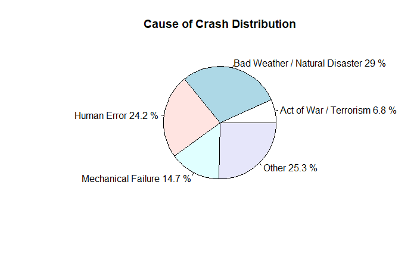

```r
cause_summary <- table(aero$Cause_Of_Crash)
percentages <- round(100 * cause_summary / sum(cause_summary), 1)

# Create labels with percentages

labels <- paste(names(cause_summary), percentages, "%", sep=" ")

# Create the pie chart
pie(cause_summary, labels = labels, main = "Cause of Crash Distribution")
```

We can see that Bad Weather / Natural Disasters and Human Error are two of the main reasons for aviation crashes. Other is the second highest and we should investigate

As cause of crash will be our target variable, we will need to encode it. Label encoding will be a good method

```r
# Label encoding Cause_Of_Crash

# Convert into a factor and then numeric
aero$Cause_Of_Crash <- as.factor(aero$Cause_Of_Crash)
aero$Cause_Of_Crash <- as.numeric(aero$Cause_Of_Crash)
```

# Create a Phase of Flight column

```r
get_Phase_of_Flight <- function(tokens) {
  tokens <- gsub("[\\.,]", "", tokens)
  tokens <- tolower(tokens)
  if("takeoff" %in% tokens || "taking" %in% tokens){
    return("Takeoff")
}else if("landing" %in% tokens || "land" %in% tokens || "landed" %in% tokens || "descending" %in% tokens)
    return("Landing")
  else{
  return("In Flight")
  }
}

aero$Phase_of_Flight <- sapply(aero$Summary, function(summary) {
  tokens <- strsplit(summary, "\\s+")[[1]]  # Split summary into tokens
  get_Phase_of_Flight(tokens)
})
```

# LDA

```r
# Load the required package
library(tm)
library(topicmodels)



# Create a corpus from the 'notes' column

my_corpus <- Corpus(VectorSource(aero$Summary))

# Perform tokenization

my_corpus <- tm_map(my_corpus, content_transformer(tolower))  # Convert to lowercase
my_corpus <- tm_map(my_corpus, removePunctuation)             # Remove punctuation
my_corpus <- tm_map(my_corpus, removeNumbers)                 # Remove numbers
my_corpus <- tm_map(my_corpus, removeWords, stopwords("en"))  # Remove common English stopwords
my_corpus <- tm_map(my_corpus, stripWhitespace)               # Remove extra whitespaces
# Inspect the first few tokens

inspect(my_corpus[1:5])
```

```
<<SimpleCorpus>>
Metadata:  corpus specific: 1, document level (indexed): 0
Content:  documents: 5

[1]  demonstration flight us army flyer flown orville wright nosedived ground height approximately feet killing lt thomas e selfridge passenger first recorded airplane fatality history one two propellers separated flight tearing loose wires bracing rudder causing loss control aircraft orville wright…
[2] first us dirigible akron exploded just offshore altitude ft test flight
[3]  first fatal airplane accident canada occurred american barnstormer john m bryant california aviator killed
[4]  airship flew thunderstorm encountered severe downdraft crashing miles north helgoland island sea ship broke two control car immediately sank drowning occupants
[5] hydrogen gas vented sucked forward engine ignited causing airship explode burn ft
```

```r
# Create a document-term matrix
dtm <- DocumentTermMatrix(my_corpus)

# Convert the DTM to a matrix
dtm_matrix <- as.matrix(dtm)

#  convert to a data frame for easier manipulation
dtm_df <- as.data.frame(dtm_matrix)

# Assign meaningful column names (terms)
colnames(dtm_df) <- make.names(colnames(dtm_df))

# Now you have your DTM ready!
```

```r
# Calculate the sum of each row in `dtm`
raw.sum <- apply(dtm, 1, sum)

# Filter out rows with zero sum (if needed)
dtm <- dtm[raw.sum != 0, ]

# Specify the number of topics (e.g., 4)
num_topics <- 6

# Fit the LDA model
lda_model <- LDA(dtm, k = num_topics)

# Get the terms associated with each topic
terms_per_topic <- terms(lda_model, 10)  # Adjust the number of terms as needed

# Assign topics to your crash notes
topic_assignments <- topics(lda_model)

# Create a new data frame with the topic assignments
aero <- data.frame(aero, topic = factor(topic_assignments))
```

```r
str(aero)
```

[output not shown]